# Mining and Validating Pre-Failure Signatures in Operational Event Logs

Alexander Apartsin<sup>1</sup>

Yehudit Aperstein<sup>2</sup>

2026-08-31

<sup>1</sup> School of Computer Science, Faculty of Sciences, Holon Institute of Technology (HIT), Holon, Israel  
<sup>2</sup> Intelligent Systems, Afeka Academic College of Engineering, Tel-Aviv, Israel

## Abstract

Every large system logs discrete operational events: errors, retries, task failures, maintenance actions. Frequent-pattern mining (FP-Growth, PrefixSpan) surfaces recurrent event patterns in these logs. We test whether pattern mining recovers precursor signatures on real industrial telemetry when the underlying failure process advances through discrete stages. The result is a signature catalog mined from six operational traces: two independent Senvion wind-farm alarm logs (Kelmarsh, Penmanshiel), Azure PdM (synthetic), Alibaba v2018 (production cloud), LLNL Blue Gene/L syslogs (HPC), and SCANIA Component X (automotive). Every signature is validated on an entity-disjoint 50/50 discovery/inference split with Benjamini-Yekutieli FDR control on the inference half, and the right-censored SCANIA trace is scored by matched conditional logistic regression stratified by risk set. The central empirical result is a replicated physical cascade: **two independent wind farms of different rotor size and site surface the same zero-control cascade signatures at inference-half lift 4.00**, selected in every repeated split and prospectively detecting 95% of Kelmarsh forced outages at a median 3.3-hour lead. A decomposition of held-out prediction into event presence, multiplicity, and order then places the two cloud/maintenance traces in opposite corners: on Azure the distinguishing increment is event **order** (+0.032, bootstrap CI excluding zero) while multiplicity adds nothing; on Alibaba it is **multiplicity** (+0.029, excluding zero) while exact order adds nothing. SCANIA yields interpretable per-truck hazard ratios (74 of 200 discovery-selected patterns survive the FDR; top HR 1.60), and BGL is a mapped boundary case with no deployable non-alert precursor. Code, splits, and all result artefacts are released.

**Keywords:** failure prediction; frequent itemset mining; sequential pattern mining; post-selection inference; false discovery rate; predictive maintenance; operational event logs.

## 1 Introduction

Operational logs from datacenters, industrial fleets, and cloud platforms carry a rich stream of discrete events: software errors, task failures, retries, eviction notices, maintenance actions, component replacements. These events are usually consumed one at a time by alerting systems and dashboards. We ask a different question: do *recurrent ordered sequences* of these events precede failures systematically enough to serve as early-warning signatures?

Two mining families answer this shape of question. Frequent itemset mining (Apriori, FP-Growth) treats each pre-failure window as an unordered set of events. Sequential pattern mining (PrefixSpan, SPADE, GSP) preserves temporal order. One methodological question runs through the paper: does the second family find anything the first does not? Its central deliverable is a catalog of validated pre-failure signatures, anchored by a physical cascade replicated across two independent wind farms.

We contribute:

1. A **matched-control frequent-pattern pipeline that separates predictive patterns from frequent noise**, with sanity invariants at every phase (random-label permutation for itemsets, within- window order shuffle for sequences), exact hypergeometric permutation p-values, and BH FDR correction on the per-pattern significance test. The predictive-vs-noise separation is the central object we characterise, not a downstream AUROC number.
2. A **generalisation of matched-control mining to right-censored survival-style data via incidence-density (risk-set) sampling** with matched conditional logistic scoring stratified by risk set, which estimates per-pattern hazard ratios without modifying the mining stage. This is the tool that lets the pipeline apply to traces where entities exit observation upon failure (Component X).
3. A **decomposition of pattern signal into event presence, multiplicity, and order**, measured directly in held-out prediction with entity-bootstrap confidence intervals, so that a repeated event folded into one itemset cannot be mistaken for an ordering effect. The decomposition places the two positive cloud/maintenance traces in opposite corners (Azure carries an order increment, Alibaba a multiplicity increment), and supports a downstream predictive evaluation against event-count, presence, count, recency, n-gram, and gradient-boosted baselines on a temporally-held-out split.
4. **Cross-dataset characterisation** on six public traces: two production wind farms (Kelmarsh, Penmanshiel), synthetic industrial per-machine (Azure PdM), real cloud per-job (Alibaba cluster-trace-v2018), real HPC per-rack (LLNL Blue Gene/L syslogs), and real automotive per-vehicle (SCANIA Component X). We report the fraction of mined patterns that pass significance on each trace, the strongest predictive signatures, and the mechanistic reason why the post-selection-valid fraction varies from 100% (Azure 24h itemsets) through 45% (Alibaba, BY-corrected) to 0% (SCANIA last20 under post-selection-valid inference).
5. A **validated signature catalog anchored by a replicated physical cascade**: two independent Senvion wind farms (Kelmarsh, Penmanshiel) produce zero-control cascade signatures at inference-half lift 4.00 under one mining protocol (§6.4), a rule learned on one farm transfers to the other (95% of outages detected in one direction), and the transfer is mechanistically selective, the vendor-shared generator-fan family carries across sites while the site-phase-specific safety family does not.

## 2 Background and related work

### 2.1 Frequent itemset and sequential pattern mining

The two mining families this paper compares are well-established. Association-rule mining introduced Apriori [1] and FP-Growth [2] over unordered transactions, the latter avoiding candidate generation through a compressed frequent-pattern tree. Sequential pattern mining extended this to ordered event streams: GSP [3] generalises Apriori-style level-wise generation to sequences; SPADE [4] uses a vertical id-list format; PrefixSpan [5] uses prefix-projected pattern growth, and is the algorithm we use in this paper.

Later variants sharpen the raw output. CM-SPAM / CM-SPADE [6] speed vertical mining through co-occurrence pruning; VMSP [7] returns only maximal sequences, compressing the pattern set without losing coverage. A recent survey [8] summarises open problems in the area. All of these algorithms are implemented in the SPMF library [9], which we call from Python for the sequence-mining half of our pipeline; the itemset half uses `mlxtend` [10].

### 2.2 Failure prediction from operational event logs

Two families of methods dominate the literature: (i) explicit frequent-pattern mining on parsed log templates, close to what this paper does, and (ii) deep learning over log sequences.

**Pattern mining.** Ren et al. [11] apply Spark FP-Growth to failure prediction on BlueGene/L, LANL-HPC, and CMRI-Hadoop logs, using event-density sliding windows over long-tail event vocabularies. İfraz and Ersöz [12] run PrefixSpan and Apriori side-by-side on a bus-fleet maintenance log, showing that sequence mining recovers “errors → replacement” trajectories that itemset mining misses. Both studies stop short of the post-selection-valid matched-control + BY-corrected + predictive-utility comparison used here, and neither touches Alibaba PdM or Azure.

**Industrial alarm-flood mining and wind-turbine alarm logs.** The process-control community mines alarm sequences directly. Hu, Wang and Wang [13] mine priority-aware closed sequential patterns to compress alarm floods into compact patterns; Hu et al. [14] adapt PrefixSpan to tolerate the short-term order ambiguity of alarm timestamps. These methods are descriptive, keyed to frequency and compactness rather than a validated pre-failure claim; our count-preserving order comparator (§4.7) is the principled test of exactly the order-vs-multiplicity ambiguity they handle heuristically, and our matched controls turn each mined pattern into an FDR-tested predictive hypothesis. On wind-turbine alarm logs specifically, Chatterjee and Dethlefs [15] predict repair actions with a bi-LSTM over turbine alarm sequences, and Shah and Tan [16] forecast future turbine alarms with LSTM regression. Both are black-box and forecast the alarm stream itself; we mine auditable pre-failure signatures on the same class of Senvion SCADA logs (Kelmarsh, Penmanshiel) with FDR guarantees and zero control-window false alarms.

**Discriminative and statistically-significant pattern mining.** Dong and Li [17] introduced emerging patterns as itemsets whose support differs substantially between classes; Bay and Pazzani [18] formulated the parallel notion of contrast sets in the same year. This class-contrast literature is a direct ancestor of the paper’s predictive-vs-frequent-noise separation. Statistically significant pattern mining sharpens the criterion: Terada et al. [19] give an exact family-wise-error control for combinatorial regulations, and the Hämäläinen-Webb tutorial [20] is the canonical statement of the multiple-testing pitfalls this class of method must handle. Recent work controls the false discovery rate directly: Dalleiger and Vreeken [21] test pattern significance against an evolving data model under sequential FDR control, and Pellegrina and Vandin [22] mine significant itemsets, sequential patterns, and subgroups with rigorous guarantees via few-shot resampling. These are our closest methodological siblings. All of these methods share the ordinary post-selection-inference concern (Fithian, Sun and Taylor [23]) that mining and testing on the same sample invalidates marginal p-values; we address it via entity-disjoint discovery/inference splits (§4.5) and add the pre-failure windowing and survival-matched design that the general-purpose significance frameworks do not model.

**Deep learning on log sequences.** DeepLog [24] frames system-log anomaly detection as next-template prediction with a stacked LSTM, and remains the canonical DL baseline. LogAnomaly [25] adds unsupervised quantitative-anomaly detection alongside sequential anomalies. LogRobust [26] adds an attention Bi-LSTM to survive log-template drift, and PLELog [27] introduces semi-supervised label estimation for the weakly-labelled setting. Recent transformer approaches (LogBERT [28]; LogFormer [29]) pre-train on unlabelled logs and fine-tune for anomaly detection; the Landauer et al. survey [30] catalogues this landscape and its benchmark datasets (including BGL). Hadadi et al. [31] give the systematic controlled study of log-embedding by architecture combinations for log-based failure prediction, the canonical modern DL baseline framing. These methods generally outperform classical pattern miners on held-out AUROC when trained on enough data, but produce opaque per-line anomaly scores rather than interpretable pre-failure signatures. Our contribution is orthogonal: we ask whether explicit ordered patterns add signal over their itemset counterparts, with every mined pattern human-readable and independently significance-tested.

### 2.3 Log-parsing infrastructure

The raw text of most system logs must first be converted into event templates before either family of methods applies. The Loghub collection [32] curates parsed versions of BGL, HDFS, Thunderbird, and 13 other benchmark log datasets; the parsing benchmark of Zhu et al. [33] compares Drain and alternative parsers on the same corpora. We take BGL from Loghub directly and use its native label field, avoiding the parsing step as a confound.

### 2.4 Failure characterisation on Alibaba and BGL

Cheng et al. [34] provide the standard characterisation of the Alibaba 2018 trace, reporting failure statistics and co-location effects but not extracting sequential patterns. Luo et al. [35] extend this to the microservice trace with focus on dependency and latency rather than fault prediction. Oliner and Stearley [36] introduce the BGL log we use, along with four other HPC logs, and characterise their alert statistics.

### 2.5 Predictive maintenance beyond system logs

The broader predictive-maintenance literature works mostly on continuous sensor telemetry. NASA C-MAPSS [37] is the de-facto Remaining-Useful-Life benchmark; recent surveys [38] catalogue the deep-learning methods trained on it. Automotive predictive maintenance has historically used per-vehicle sensor snapshots (SCANIA APS Failure via the IDA 2016 industrial challenge [39]); the SCANIA Component X release [40] we adopt extends this to a per-vehicle longitudinal readout stream. Our work sits between these traditions: we take discrete-event traces where possible, and derive discrete tokens (per §3.6) where we must.

### 2.6 Statistical significance

We apply Benjamini-Hochberg FDR correction [41] to the one-sided hypergeometric p-values on the inference half of the discovery/inference split (§4.5). For arbitrary dependence between p-values (justified when mined patterns share items), we also report the more conservative Benjamini-Yekutieli correction [42]. The Prentice-Breslow retrospective-cohort framework [43] and the Langholz-Goldstein risk-set-sampling review [44] motivate the matched conditional logistic estimator we use for SCANIA (§4.6).

### 2.7 Positioning

The paper’s contribution is a single methodological package applied uniformly across six traces: entity-disjoint post-selection-valid mining, a count-preserving order null that separates ordering from event multiplicity, and a censoring-valid matched conditional logistic estimator for right-censored entities, evaluated against an event-count baseline and each pattern family in turn on a temporally- held-out split. To our knowledge, this package has not been applied head-to-head to Alibaba `batch_task` status transitions or to Azure PdM `errorID → failure` sequences, and the six-trace regime-of- validity study of §7.2, anchored by a cascade replicated across two independent wind farms, is likewise unprecedented in the pattern-mining log-analysis literature.

## 3 Data

We use six public traces: two wind-farm alarm logs, one synthetic industrial-maintenance trace, one production cloud trace, one HPC syslog corpus, and one automotive fleet trace.

### 3.1 Kelmarsh wind-farm alarm logs (production, per-turbine)

Six Senvion MM92 wind turbines at the Kelmarsh site, released by Plumley 2022 [45] via Zenodo record 5841834 under CC-BY-4.0. Each turbine’s status log carries every alarm/event that the SCADA emitted over the year, together with an IEC category (`Full Performance`, `Forced outage`, `Out of Environmental Specification`, …).

Across 2016-2017 the six turbines produced 63,633 status events, of which 482 were tagged `Forced outage` (real physical failures: generator-fan overloads, frequency-converter faults, safety-chain openings). Top forced-outage codes across the fleet: `2550` Overload generator fan 1, `2650` Overload generator fan 2, `2655` Overload generator fan 3, `3000` Frequency converter not ready, `100` Safety chain open. Non-forced-outage codes that appear as warnings or stops are the natural precursor candidates: `5720` Brake accumulator defect, `2125` Timeout brake closed, and the same overload-fan codes that later terminate the cascade.

Event vocabulary: `system_stop`, `system_warning`, `system_info`, `system_comm`, `terminal_failure`. Entity is the turbine (`T1`..`T6`), subtype is the numeric fault code. Failure event = `terminal_failure` placed at each Forced-outage timestamp.

This trace is the paper’s cleanest realisation of the physical- cascade shape: the alarm-code progression is consistent with a physical fault cascade, in which intermediate warning codes precede a specific alarm that terminates as a Forced outage. We report the statistical enrichment and the code semantics; the underlying wear mechanism is an engineering interpretation, not something the logs alone establish.

### 3.2 Penmanshiel wind-farm alarm logs (production, per-turbine)

Nine of the fourteen Senvion MM82 turbines at the Penmanshiel site (Cubico Sustainable Investments; Plumley 2022 [46] Zenodo record 5946808 under CC-BY-4.0), same Greenbyte SCADA schema as Kelmarsh. We use the nine turbines (of identifiers P01-P15, with P03 absent from the release) whose status logs cover the 2016 window; for the second half of 2016 (2016-06 through 2016-12, when the site went live) they produced 15,388 status events, of which 790 were tagged `Forced outage`. This is the paper’s largest single-year forced-outage count on a physical cascade trace, and the alarm vocabulary is Senvion-shared with Kelmarsh, so Penmanshiel is an independent replication of the Kelmarsh cascade finding on turbines of a different rotor size (MM82 vs MM92) at a site with different terrain and weather.

Entity is the turbine (`P01`..`P15`, `P03` is not in the release), subtype is the numeric fault code.

### 3.3 Azure Predictive Maintenance (synthetic, per-machine)

100 machines, 2015-01-01 to 2016-01-01, hourly telemetry. `PdM_errors` (3,919 non-fatal errors, five error codes), `PdM_maint` (3,286 maintenance actions, four components), `PdM_failures` (761 component replacements). We join `PdM_maint` and `PdM_failures` on (machineID, datetime, comp) to distinguish `maintenance` from `component_replacement`. Failures at exactly 2015-01-02 03:00 (18 rows) do not match any `PdM_maint` record; they are a bootstrap seed batch planted by the synthetic generator and are excluded from both anchors and event streams so they do not contaminate windows for subsequent real failures.

Event vocabulary: `software_error`, `maintenance`, `component_replacement`, `terminal_failure`, each with a subtype (`error1..error5`, `comp1..comp4`). Entity is `machineID`. Source: [47].

### 3.4 Alibaba cluster-trace-v2018 (production cloud, per-job)

`batch_task.csv` from the public Alibaba trace [48, 49], 14,295,731 tasks across 4,201,014 jobs, 8.9 days (2018-01-01 through 2018-01-09 by trace clock). 83,207 jobs contain at least one `Failed` task. `batch_instance.csv` (21 GB compressed) is not used in this pass; the per-job analysis on `batch_task` alone is sufficient to answer the ordering question.

Event vocabulary: `task_failure`, `task_success`, `task_waiting`, `task_running`, each with subtype = task_name letter prefix (`M`, `R`, `J`, `task`, `MergeTask`, `L`). Entity is `job_name`.

### 3.5 LLNL Blue Gene/L syslogs (Loghub, per-rack)

4,747,963 syslog messages from LLNL Blue Gene/L, 214.7 days (2005-06-03 to 2006-01-04), from the Loghub archive [32, 36]. 913,594 messages remain after dropping INFO-level noise; 348,189 (7.34%) are labelled alerts. Entity is the rack (top-level `R##` prefix of the node ID); 64 racks. Event vocabulary: `terminal_alert` (labelled alerts with 30+ alert codes such as KERNMNTF, APPTO, KERNSTOR), `system_error` (non-alert FATAL / ERROR / SEVERE / FAILURE), `system_warning`. Component (RAS, KERNEL, APP, MMCS, …) is used as an additional subtype axis.

### 3.6 SCANIA Component X (production automotive, per-vehicle)

Real fleet telematics dataset released 2025 [40], 23,550 trucks over 1.5 years (2019-01 through 2020-05 in study clock), 1,122,452 readouts of 105 numeric counter and histogram features. 2,272 vehicles (9.65%) undergo a component X repair during the study.

Because features are numeric counters rather than native discrete events, we derive tokens: for each (vehicle, feature) we compute inter-readout deltas and emit a `counter_surprise` token per readout whenever the absolute delta exceeds the vehicle’s own 90th-percentile threshold for that feature. Per-vehicle normalisation controls for baseline usage variation across the fleet. Entity is `vehicle_id`. The failure event is a synthetic `terminal_repair` marker placed at the last readout timestamp of each repair-labelled vehicle.

## 4 Method

The same pipeline is applied to every trace (Figure 1): pre-failure windows with matched controls, an entity-disjoint discovery/inference split, mining on the discovery half, and post-selection-valid scoring with FDR control on the inference half. The right-censored SCANIA trace additionally uses risk-set matched sampling and matched conditional logistic regression.

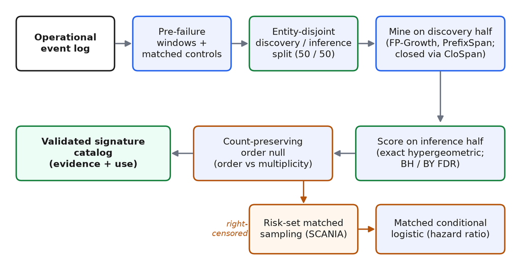

**Figure 1.** The mining and validation pipeline applied uniformly to every trace. Pattern discovery runs on the discovery half; every mined pattern is then scored on the disjoint inference half with an exact hypergeometric test and BH / BY false-discovery control. The count-preserving order null separates ordering from event multiplicity, and the right-censored SCANIA trace branches to risk-set matched sampling with a matched conditional logistic estimator.

### 4.1 Pre-failure windows and matched controls

For every terminal failure event on an entity (machine on Azure, job on Alibaba, rack on BGL, vehicle on SCANIA, turbine on Kelmarsh and Penmanshiel), we build a failure window covering the K events (or the time horizon T) strictly before the failure timestamp. Matched controls come from two designs depending on the trace:

- **Same-entity clean regions** (Azure, BGL, Kelmarsh, Penmanshiel) when the entity carries long timelines with sparse failures; controls are anchored at times on the same entity with no failure within horizon T in either direction, sampled at a 1:3 case-to-control ratio.
- **Cross-entity non-failure sample** (Alibaba, SCANIA) when entities are short-lived; controls come from the last K events of a non-failure entity, sampled at a 1:3 case-to-control ratio from a large candidate pool.

The two wind farms use the same-entity design over each turbine’s multi-year alarm timeline: failure windows are anchored on each Forced-outage event and controls on same-turbine clean regions. The entity-disjoint discovery/inference split (§4.5) partitions turbines 3-and-3 on Kelmarsh (6 turbines) and 4-and-5 on Penmanshiel (9 turbines), so no turbine contributes to both mining and inference; the resulting inference half carries 233 failure and 699 control windows at `last5`/`last10` on Kelmarsh and 448 failure and 1,344 control windows on Penmanshiel.

BGL alerts are additionally grouped into episodes (>= 1h inter-arrival gap) and windows are anchored on the first alert of each episode, so anchor-per-alert double-counting inside a cascade is avoided.

Horizons studied: `1h`, `6h`, `24h`, `last5`, `last10` on Azure and on the two wind farms; `last3`, `last5`, `last10` on Alibaba; `last5`, `last10`, `last20` on BGL and SCANIA (time-based horizons are not meaningful for short per-job or per-episode observations).

### 4.2 Mining

Items are `event_type:event_subtype` strings. FP-Growth (`mlxtend.frequent_patterns.fpgrowth`) mines frequent itemsets on failure windows at minimum support 0.05. PrefixSpan (SPMF v2.64 [9] via subprocess) mines frequent ordered sequences at the same support.

For each mined pattern P we compute support in failure windows (support_failure), support in control windows (support_control), lift = support_failure / pooled_support(P), and relative risk = P(failure | P) / P(failure | ¬P). Every mined sequence is also scored against the itemset counterpart of the same event set; the difference `order_gain = sequence_lift - itemset_lift` quantifies how much preserving order contributes above co-occurrence.

### 4.3 Sanity invariants

Every phase carries pre-declared invariants whose expected outcome is stated up front. Itemset mining checks that a random-label permutation at the same minimum support does not yield a top lift within a factor of 1.5× of the real top lift; a violation would indicate either data leakage or an over-sensitive support threshold. Sequence mining checks that a within-window random order permutation preserves top itemset lift (unchanged, by construction) but strictly reduces top sequence lift on rich horizons (windows with >= 3 events on average). Both invariants pass on the two cloud and maintenance traces (Azure, Alibaba); on the boundary traces the same invariants localise where the signal fails, rather than requiring post-hoc justification.

### 4.4 Risk-set matched sampling for right-censored data

The matched-control design in §4.1 assumes we can define a “no-failure” control window on the same or another entity at the anchor time. For right-censored survival-style data (traces where entities exit observation upon repair or dropout), naive matching biases scoring because “did we observe a failure” becomes entangled with “how long did we observe the truck”. Component X in §3.6 has exactly this problem: short-observation trucks have 12% failure rate; long-observation trucks have 5%.

Following the epidemiological literature on incidence-density sampling [43, 50], we replace §4.1’s sampler with a risk-set matched design: for each case with observed failure time T_f, controls are drawn from the risk set at T_f (the set of entities still under observation at that lifetime index) and their windows are aligned to T_f rather than to their own end-of-observation. Both case and control windows use the last K events with time_step < T_f. Under this sampling, the pooled 2×2 odds ratio of a mined pattern (case-in vs case-out; control-in vs control-out, Woolf-Haldane 0.5-continuity-corrected, 95% CI via log-OR variance) estimates the per-pattern hazard ratio rather than a prevalence lift. A mined pattern with MH-OR > 1 and 95% CI excluding 1 is a censoring-valid signal of elevated failure risk, not an artefact of the observation process.

The rest of the pipeline runs unchanged: FP-Growth on the risk-set windows, minimum support 0.05, BH FDR correction on the p-values induced by the Fisher-exact null of the same 2×2 table. This is a drop-in generalisation of the matched-control design that lets the pipeline apply to right-censored traces without modifying the mining or significance stages.

### 4.5 Post-selection-valid significance via discovery/inference splits

Mining patterns from failure windows and then computing hypergeometric p-values on the same failure/control counts yields post-selection- invalid marginal p-values: the candidate set is chosen because it has high support in failure windows, so the fixed-hit-set null is not the null the pipeline actually operates under. BH or BY correction on those marginal p-values does not restore validity [23, 51].

Our fix, applied to every trace: split the training set entity- disjoint into a 50% **discovery** half and a 50% **inference** half. FP-Growth / PrefixSpan run on the discovery half and produce a candidate pattern universe C. Every P in C is then scored on the inference half via exact hypergeometric p-value on that half’s case/control hit counts alone. Because C is chosen without touching the inference half, the resulting p-values are marginally valid and BH / BY correction on the family {p(P) : P in C} controls the inference-half FDR correctly.

Entity-disjoint splitting is used rather than random per-window splitting because otherwise the same entity’s windows could appear on both sides of the split, leaking information from discovery into inference. On Alibaba specifically the entity unit is the batch job: each job contributes exactly three windows, one per horizon (`last3`, `last5`, `last10`), and each job is either a case (job that subsequently failed) or a control, never both; the 64,948 unique jobs give a 1:3 case-to-control balance by design (16,237 failed jobs, 48,711 controls). Splitting on `entity_id` (job id) therefore produces truly disjoint discovery and inference halves at both the entity and the window level.

### 4.6 Matched conditional logistic for risk-set traces

A pooled 2×2 odds ratio over the risk-set-matched SCANIA patterns discards the matched-set structure that makes the estimator censoring-valid. The standard estimator under incidence- density (risk-set) sampling is a conditional logistic regression stratified by matched set, equivalent to the sampled Cox partial likelihood restricted to the pattern indicator [43, 44]. We estimate every SCANIA pattern’s coefficient with `statsmodels.ConditionalLogit` stratified by `match_id`; each case and its three risk-set-matched controls form one stratum. Reported hazard ratios and 95% CIs are from that matched fit.

Compared to the pooled 2×2 Woolf-Haldane analysis, the matched estimator is more conservative on this data: a top pattern that scores MH-OR 2.72 [2.10, 3.51] under pooling scores a matched HR in the 1.6-1.7 range under conditional logistic, and the honest inference-half estimate (§6.11) is a top HR of 1.60 [1.35, 1.91].

### 4.7 Count-preserving order comparator

The naive `order_gain = sequence_lift − itemset_lift` compares a sequence like `M → M → M` against its itemset counterpart `{M}`, which collapses three occurrences to one presence. That conflates temporal order with event multiplicity. Our count-preserving comparator shuffles the ordering within each window while preserving the exact event multiset per window, then rescores the sequence’s support on the shuffled corpus. The residual `order_effect = real_lift − mean(count-preserving-shuffle_lift)` isolates the pure ordering contribution.

### 4.8 Statistical significance summary

For each mined pattern we compute an exact one-sided hypergeometric p-value on the observed failure-hit count against the label-permutation null with the pattern hit-set fixed. Under H0 the number of hits landing in the failure class is Hypergeom(N_F+N_C, hit_F+hit_C, N_F); the upper-tail probability of the observed hit count *is* the label-permutation p-value, so we compute it in closed form. Benjamini-Hochberg FDR correction [41] is applied per (horizon × pattern class) to give q-values.

## 5 Experiments

Windows are split temporally by anchor timestamp. Cutoffs: Azure 2015-09-01, Alibaba 2018-01-07, BGL 2005-11-01, SCANIA 2020-01-01. Mining runs on training windows only; surviving patterns become binary presence features on both train and test. A logistic regression fit on train is evaluated on test for four feature sets:

- **event_count**: single feature, n_events in the window
- **itemsets_only**: binary presence of each train-mined itemset surviving its permutation null
- **sequences_only**: binary presence of each train-mined sequence surviving its shuffle null
- **combined**: union of the event-count, itemset, and sequence feature sets above

For each configuration we report AUROC, AUPRC, F1 / precision / recall at threshold 0.5, and lead time (anchor − last_event_ts) on true-positive failure windows. Numbers are computed in a single pass per configuration and stored as one artefact, so a comparison across feature sets on the same trace cannot drift.

### 5.1 Coverage per horizon (Azure)

Time horizons of 1h and 6h leave 99.6% and 98% of failure windows empty. Effectively no Azure PdM failure is preceded by an event in the same hour. Useful horizons are 24h and the count-based (`last5`, `last10`). Even at 24h, failure and control windows separate cleanly by raw event count (failure mean 1.58 events, control mean 0.077; Figure 2).

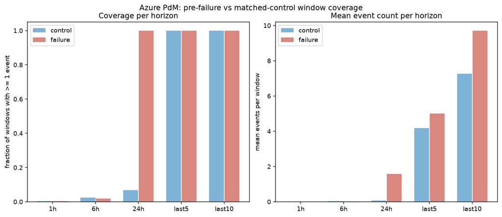

**Figure 2.** Event coverage of Azure pre-failure windows by horizon: the mean number of events per window grows with horizon length, which sets how much order information each horizon can carry.

### 5.2 Mining sensitivity to minimum support (Azure)

A minimum support sweep over {0.02, 0.05, 0.10, 0.15} preserves the headline ordering at every operating point (Table 1):

**Table 1.** Predictive AUROC on Azure by feature set across the FP-Growth minimum-support sweep.

| horizon | metric | 0.02 | 0.05 | 0.10 | 0.15 |
| --- | --- | --- | --- | --- | --- |
| 24h | combined | 0.996 | 0.996 | 0.996 | 0.996 |
| 24h | itemsets_only | 0.996 | 0.996 | 0.996 | 0.996 |
| last5 | combined | 0.815 | 0.810 | 0.803 | 0.774 |
| last5 | itemsets_only | 0.761 | 0.754 | 0.762 | 0.754 |
| last10 | combined | 0.664 | 0.696 | 0.751 | 0.741 |
| last10 | itemsets_only | 0.578 | 0.643 | 0.686 | 0.674 |

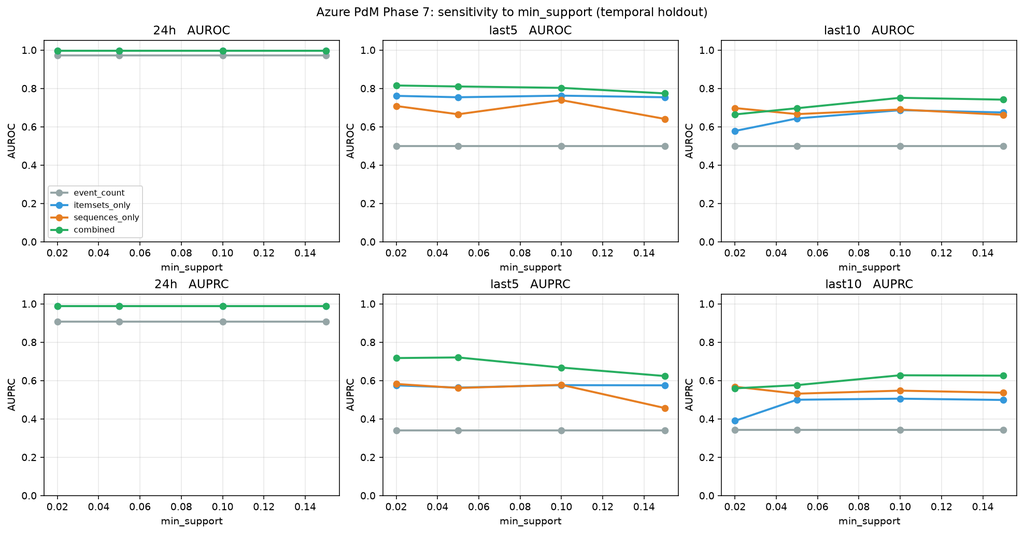

**Figure 3.** Predictive AUROC on Azure across the FP-Growth minimum-support sweep. Combined itemset-plus-sequence features lead the itemset-only and event-count baselines at every threshold.

## 6 Results

### 6.1 Mined patterns (Azure and Alibaba)

At Azure 24h, `{software_error:error2, software_error:error3}` reaches lift 3.99 (present in 38.2% of failure windows, in 0.04% of controls on the full training sample; the disjoint inference half in §6.4 gives zero control hits; P(failure | pattern) = 99.6%). All six 24h itemsets dominate the random-label permutation null (permuted top 1.24).

At Azure `last5`/`last10`, the sequence `maintenance:comp4 → software_error:error2 → software_error:error3` reaches lift 3.73 as an ordered pattern but only 2.22 as the same items unordered. Ordered patterns ending `... → error2 → error3` dominate the top-8 at both count-based horizons (Figure 4).

On Alibaba `last3`, `task_success:M → task_success:M → task_success:M` reaches sequence lift 3.06 versus itemset lift 1.37 for the binary presence of `{M}`: three consecutive Map completions predict a subsequent failure much more strongly than the mere presence of a Map event. This is a **multiplicity** effect, not an ordering effect: the binary itemset `{M}` discards the repeat count, and the count-preserving null of §6.3 plus the decomposition of Table 3 confirm that the exact within-window order of the three Map events adds no further signal on Alibaba (order increment -0.006, CI [-0.022, 0.013]).

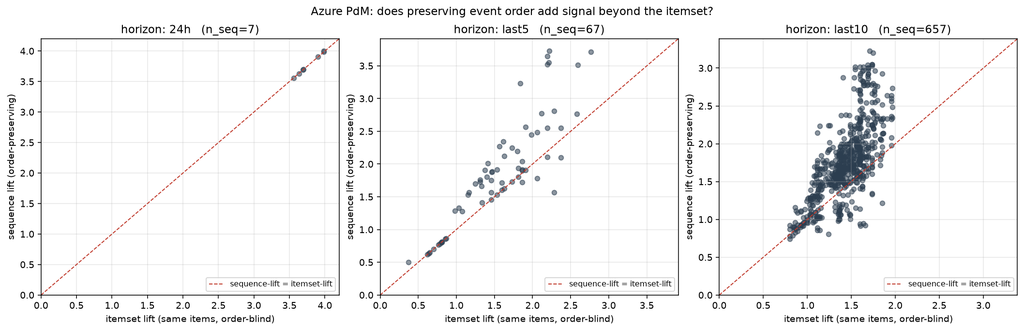

**Figure 4.** Itemset lift versus sequence lift for Azure patterns. Points above the diagonal are patterns whose ordered form carries more failure signal than their unordered co-occurrence, the effect the count-preserving null of §4.7 isolates.

### 6.2 Predictive evaluation (four temporally-split traces)

Head-to-head on temporally-held-out test sets (Figure 5; the two wind farms are evaluated via the discovery/inference signature protocol of §6.4, not this temporal-split predictive table; Table 2):

**Table 2.** Held-out AUROC / AUPRC by feature set on the four temporally-split traces.

| trace | horizon | event_count | itemsets_only | sequences_only | combined |
| --- | --- | --- | --- | --- | --- |
| Azure | 24h | 0.97 / 0.91 | 0.996 / 0.99 | n/a | 0.996 / 0.99 |
| Azure | last5 | 0.50 / 0.34 | 0.75 / 0.56 | 0.66 / 0.56 | **0.81 / 0.72** |
| Azure | last10 | 0.50 / 0.34 | 0.64 / 0.50 | 0.67 / 0.53 | **0.70 / 0.58** |
| Alibaba | last3 | 0.69 / 0.50 | 0.75 / 0.44 | 0.50 / 0.20 | **0.81 / 0.63** |
| Alibaba | last5 | 0.60 / 0.50 | 0.67 / 0.34 | 0.51 / 0.21 | **0.74 / 0.57** |
| Alibaba | last10 | 0.59 / 0.50 | 0.68 / 0.36 | 0.52 / 0.23 | **0.74 / 0.59** |
| BGL | last5 | 0.50 / 0.25 | 0.49 / 0.25 | n/a | 0.49 / 0.25 |
| BGL | last10 | 0.50 / 0.25 | 0.49 / 0.25 | 0.50 / 0.25 | 0.50 / 0.25 |
| BGL | last20 | 0.50 / 0.25 | 0.48 / 0.25 | 0.50 / 0.25 | 0.51 / 0.26 |
| SCANIA | last5 | 0.50 / 0.09 | 0.52 / 0.11 | n/a | 0.52 / 0.11 |
| SCANIA | last10 | 0.50 / 0.09 | 0.60 / 0.14 | 0.55 / 0.11 | 0.60 / 0.15 |
| SCANIA | last20 | 0.50 / 0.09 | 0.57 / 0.14 | 0.53 / 0.10 | 0.57 / 0.13 |

*(AUROC / AUPRC on the temporally-held-out test set. A `sequences_only` cell reads `n/a` when no sequence survived the training-set shuffle null at that configuration, so no sequence feature was available; `combined` then equals `itemsets_only`. SCANIA uses per-vehicle 90th-percentile-delta binning; BGL uses episode-anchored per-rack windows with alerts removed from the pre-alert stream. Both boundary traces sit near chance for every feature set at every horizon.)*

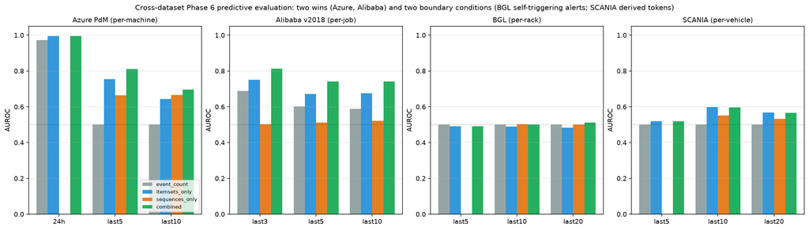

**Figure 5.** Held-out predictive AUROC by feature set across the four temporally-split traces (Azure, Alibaba, BGL, SCANIA). The combined feature set leads on Azure and Alibaba; BGL and SCANIA sit at the no-signal boundary.

### 6.3 Presence, multiplicity, or order

A mined pattern can carry predictive signal through three distinct channels: which event types are **present** (a set), how many times each occurs (**multiplicity**, a multiset), and the **order** in which they occur (a sequence). The count-preserving null of §4.7 already isolates order at the level of individual pattern lift; here we measure all three channels directly in held-out predictive AUROC, so that a “sequence helps” claim cannot be an artifact of repeated events being folded into one itemset. On the temporal test split of each trace we build nested representations from the same windows with the vocabulary fixed on the training period: binary presence (set), event counts (multiset), and binary adjacent bigrams (order), each scored by L2 logistic regression, and read off two incremental effects with entity-bootstrap 95% CIs (resampling test turbines/machines/racks, B = 200): the **multiplicity increment** (counts over presence) and the **order increment** (bigrams over counts) (Table 3).

**Table 3.** Presence / multiplicity / order decomposition of held-out AUROC, with entity-bootstrap 95% CIs. A component whose interval excludes zero is a distinguishable channel of signal.

| trace | presence effect | multiplicity increment | order increment |
| --- | --- | --- | --- |
| Kelmarsh | **+0.244 [0.195, 0.315]** | -0.004 [-0.038, 0.021] | -0.018 [-0.023, 0.002] |
| Penmanshiel | **+0.326 [0.282, 0.374]** | +0.003 [-0.016, 0.023] | +0.002 [-0.048, 0.037] |
| Azure | +0.301 [0.258, 0.332] | +0.012 [-0.015, 0.034] | **+0.032 [0.003, 0.061]** |
| Alibaba | +0.149 [0.128, 0.171] | **+0.029 [0.018, 0.040]** | -0.006 [-0.022, 0.013] |
| BGL | -0.015 [-0.032, -0.001] | +0.000 [-0.001, 0.001] | +0.024 [0.002, 0.044] |
| SCANIA | +0.062 [0.028, 0.097] | +0.020 [0.007, 0.036] | -0.075 [-0.109, -0.037] |

The decomposition separates the traces into three clean regimes. **On the two wind farms the entire signal is event presence** (+0.244 on Kelmarsh, +0.326 on Penmanshiel, both large and with CIs far from zero), and both the multiplicity and order increments are indistinguishable from zero: which alarm codes occur is what predicts the outage, not how many times or in what order. This is the decomposition’s account of the co-located burst, and it is exactly why the search for ordered degradation trajectories below returns so little. **On Azure and Alibaba a large presence effect is joined by exactly one further channel: order on Azure (+0.032, CI excludes zero, multiplicity does not), multiplicity on Alibaba (+0.029, excludes zero, order does not)** (Figure 6). Azure carries a genuine ordering signal; Alibaba a multiplicity signal that binary itemsets discard but exact order does not recover, which resolves the tension with the count-preserving lift analysis below (the Alibaba sequence advantage is repeated-event information, not exact order).

An increment channel is only meaningful when it sits on a presence base that itself clears the floor: a channel CI that excludes zero on top of a floor-level presence effect moves a near-chance prediction to a slightly-less-near-chance prediction, not a usable signal. BGL illustrates this. Its order increment is +0.024 with a CI that excludes zero, numerically like Azure’s, but its presence effect is negative (-0.015) and its total AUROC never leaves 0.48 to 0.51, so the order channel has no base to build on. SCANIA shows the opposite failure: a significantly negative order increment (-0.075), meaning bigram features actively hurt once counts are included, on a presence base (+0.06) that is itself near the floor. The distinguishing-channel claim is therefore made jointly with the presence base, not from a single CI: the two wind farms have a large presence base and no further channel, Azure and Alibaba have a large presence base and exactly one further channel each, and BGL and SCANIA have no usable presence base for any channel to build on.

Against non-degenerate baselines the mined-pattern features do not win on raw accuracy, and we do not claim they do. All numbers in this paragraph and in Table 3 come from one internally consistent evaluation pass (the same windows, temporal split, and vocabulary for every representation), which differs slightly from the separate predictive pipeline of Table 2, so its mined-itemset AUROC (0.778 on Azure `last5`) is not identical to Table 2’s (0.75); the comparison that matters is between representations computed together. On Azure `last5` a gradient-boosted model on event counts and a binary-bigram logistic regression both reach AUROC 0.845, above the mined-itemset features (0.778); on Alibaba `last3` the gradient-boosted count model reaches 0.883, well above the mined-itemset features (0.695). The recency baseline (event count plus window time span) stays near 0.57-0.70. The value of the mined patterns is therefore not that they maximise a held-out score, which a count-vector gradient-boosted model already does, but that they are human-readable, individually significance-tested signatures that occupy a specific point on the accuracy-interpretability frontier and expose the presence / multiplicity / order structure a black-box score hides.

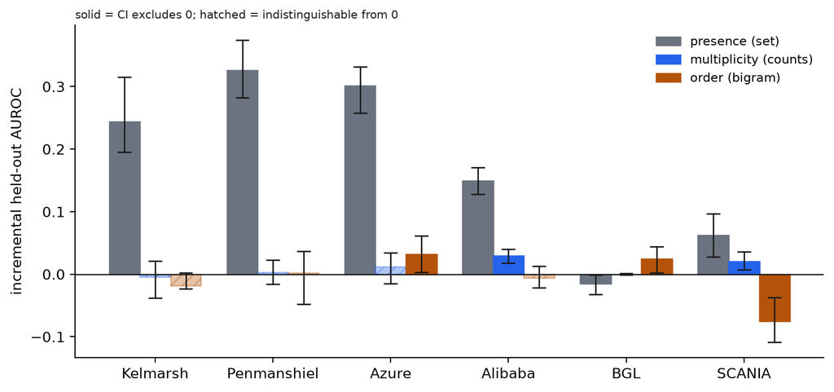

**Figure 6.** Presence / multiplicity / order decomposition of held-out AUROC across all six traces, with entity-bootstrap 95% CIs. Solid bars have a CI excluding zero; hatched bars are indistinguishable from no effect. The two wind farms are pure presence; Azure adds an order increment, Alibaba a multiplicity increment; BGL and SCANIA have no usable presence base.

The count-preserving comparator of §4.7 isolates the pure ordering contribution at the level of individual pattern lift as `order effect = real_lift − mean(count-preserving-shuffle_lift)`. Top-20 sequences per horizon (Table 4):

**Table 4.** Order effect under the count-preserving null: real lift, shuffled-null lift, and their difference.

| trace | horizon | real lift | count-preserving null lift | order effect |
| --- | --- | --- | --- | --- |
| Azure | last5 | 2.85 | 2.33 | **+0.52** |
| Azure | last10 | 3.01 | 1.92 | **+1.09** |
| Alibaba | last3 | 1.91 | 1.93 | −0.02 (null) |
| Alibaba | last5 | 1.73 | 1.71 | +0.02 (null) |
| Alibaba | last10 | 2.09 | 1.85 | +0.24 |

Reading these against the naive `order_gain` values (up to +1.69 on Alibaba `last3`), the count-preserving comparator shows that essentially all of the reported Alibaba “order gain” was a multiplicity effect: the same event multiset in any order carries approximately the same lift as the specific ordered sequence. Azure `error2 → error3`-terminating sequences retain a genuine ordering effect of +0.5 to +1.1 lift units above the count-preserving null. Order is a real signal on Azure and essentially not a signal on Alibaba once multiplicity is controlled for.

### 6.4 Signature catalog: mined patterns, evidence, interpretation, use

The paper’s central deliverable is a catalog of failure-precursor signatures. Each signature is a specific mined pattern for which we present statistical evidence, a domain-specific interpretation, and an intended deployment use. The catalog is built from all six traces’ mining output using the safeguards of §4.5 (post-selection-valid inference on the disjoint inference half), §4.6 (matched conditional logistic for the right-censored SCANIA trace) and §4.7 (count-preserving comparator for order effect). Every signature is a specific pattern grounded in its trace, not a cross-trace generalisation. The remainder of §6 walks through the catalog by trace.

**Kelmarsh wind turbines.** Kelmarsh yields the strongest cascade signatures in the catalog. All top signatures have zero control hits on the inference half, and each fault code names a specific mechanical or electrical precursor of the same-family Forced-outage event.

Mining on the discovery half at 5% minimum support then scoring on the inference half of the 2016-2017 fleet (233 fail / 699 ctrl windows at `last5`, same at `last10`), 30/35 `last5` itemsets and 113/136 `last10` itemsets pass BY q<0.05 (Table 5).

**Table 5.** Top Kelmarsh generator-fan signatures on the inference half.

| horizon | pattern (code:message) | inf-half lift | BY q | n_case | n_ctrl |
| --- | --- | --- | --- | --- | --- |
| last5 | `terminal_failure:2550` (Overload gen fan 1) | 4.00 | 1.4e-18 | 32 | 0 |
| last5 | `system_warning:2550` (Overload gen fan 1, standalone warning) | 4.00 | 4.9e-16 | 27 | 0 |
| last5 | `system_warning:2655` (Overload gen fan 3) | 4.00 | 1.9e-14 | 24 | 0 |
| last10 | `terminal_failure:2550` | 4.00 | 1.9e-26 | 45 | 0 |
| last10 | `terminal_failure:2655` | 4.00 | 9.6e-25 | 42 | 0 |
| last10 | `system_warning:2655 + terminal_failure:2655` | 4.00 | 2.7e-23 | 39 | 0 |
| last10 | `terminal_failure:2650 + terminal_failure:2655` | 4.00 | 2.1e-18 | 31 | 0 |
| 6h | `system_warning:2000 + terminal_failure:2550 + terminal_failure:2650` (long-fault-chain terminal group) | 4.00 | 3.5e-12 | 20 | 0 |

Windows are strictly pre-anchor, so a `terminal_failure` token inside a window is a *prior* forced outage, not the anchor being predicted. The table therefore contains two distinct signature families, both at lift 4.00 with zero control hits. The first is **repeat-outage clustering**: a recent same-code generator-fan outage (`terminal_failure:2550`, `terminal_failure:2655`) strongly predicts the next, so these outages recur in bursts on the same turbine (45 `last10` cases, 0 controls for `terminal_failure:2550`). The second, and the operationally decisive one, is **warning-to-outage precursors**: the pure generator-fan overload warning codes `system_warning:2550` and `system_warning:2655` precede the same-family Forced outage before any outage has occurred (24 `last5` cases, 0 controls for `system_warning:2655`). This is the paper’s driving hypothesis in its clearest form: a physical wear process raises generator-fan overload warnings at an intermediate stage before the same fault terminates the cascade as a Forced outage.

Use: two rules with different triggers. **Early warning**: schedule generator cooling and bearing inspection the moment `system_warning:2550` or `system_warning:2655` fires, before any outage. **Escalation**: after a generator-fan Forced outage, treat a second on the same turbine as imminent (the repeat-outage family). Both rules have zero false alarms over the 699 inference-half control windows at `last5`; §6.5 quantifies how much of the escalation signal the last-event baseline already captures. Figure 7 shows one such episode.

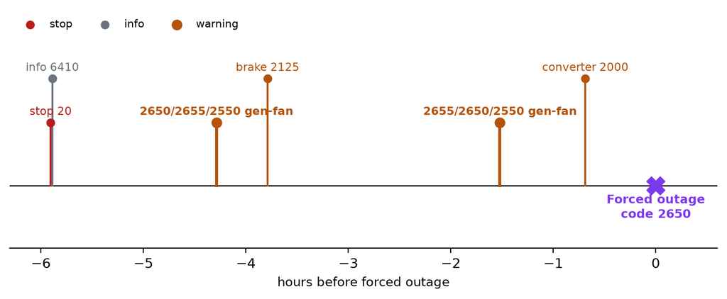

**Figure 7.** A real generator-fan overload cascade on Kelmarsh turbine T3. The co-occurring warning codes 2550, 2650, and 2655 (generator fans 1, 2, and 3) fire together twice in the hours before a same-family Forced outage (code 2650), alongside brake and frequency-converter alarms. This co-occurrence is the itemset signature the catalog records; the terminal marker at hour 0 is the outage being predicted.

**Penmanshiel wind turbines (independent replication).** Nine Senvion MM82 turbines over 2016-06 to 2016-12. Fresh entity-disjoint split: 448 fail / 1,344 ctrl windows at `last5`. Signatures replicate Kelmarsh in shape (zero-control cascades at lift 4.00) with a different code family driving the leaderboard (safety-system 9000/9210 codes and frequency-converter 3000 codes), consistent with the Penmanshiel fleet’s known 2016 commissioning-phase safety-system teething (Table 6).

**Table 6.** Top Penmanshiel signatures on the inference half.

| horizon | pattern | inf-half lift | BY q | n_case | n_ctrl |
| --- | --- | --- | --- | --- | --- |
| last5 | `system_warning:9000 + terminal_failure:9210` | 4.00 | 1.4e-43 | 70 | 0 |
| last5 | `system_info:0 + system_warning:9000 + terminal_failure:9210` | 4.00 | 1.4e-43 | 70 | 0 |
| last5 | `system_stop:9210 + system_warning:9000` | 4.00 | 1.5e-34 | 56 | 0 |
| last10 | `system_info:3543 + system_stop:3000 + terminal_failure:3000` (freq-converter chain) | 4.00 | 2.2e-11 | 19 | 0 |
| last10 | `system_info:3543 + system_warning:5720 + terminal_failure:3000` | 4.00 | 2.2e-11 | 19 | 0 |
| 6h | `system_stop:9210` (safety-9210 group) | 4.00 | 1.3e-98 | 150 | 0 |
| 6h | `system_stop:9210 + terminal_failure:9210` | 4.00 | 1.3e-98 | 150 | 0 |

Interpretation: as on Kelmarsh, rows carrying a `terminal_failure` token are prior-outage clustering, while the pure warning and info-to-stop rows are the actionable precursors. **The pure warning code `system_warning:9000` precedes the safety-system 9210 Forced outage, and the safety-stop `system_stop:9210` reaches 150 inference-half forced-outage windows with zero hits across 1,344 matched controls**. The frequency-converter chain `system_info:3543 -> system_stop:3000` is an independent second precursor family with 19 zero-control replications. Combined with Kelmarsh, this is the first cross-farm cascade replication in the paper: two different turbine models on two different sites both produce lift-4.00 cascade signatures under the same mining protocol, with vendor-shared alarm codes indexing genuinely mechanical failure modes.

Candidate rules (pending prospective trial): the safety-9210 warning is a candidate curtailment trigger and the frequency-converter 3543 informational message a candidate converter-service trigger. The co-located Penmanshiel burst has a short median lead, so it often fires too late for curtailment; the small number of validated degradation chains next, and the prospective replay below, are where a longer actionable lead has to come from.

**Table 7.** The degradation chains that survive prior-outage exclusion, closed-chain filtering, and the incremental-over-terminal-code test on the 24h inference half. Each chain is more control-specific than its own terminal code; the lift equals the inference-half ceiling (2.9 on Kelmarsh at 60 cases to 113 controls, 2.2 on Penmanshiel), because every listed chain has zero or one control hit.

| farm | degradation chain (24h, contamination-guarded) | median lead | terminal code alone | chain ctrl | inf case |
| --- | --- | --- | --- | --- | --- |
| Kelmarsh | `info:10 → info:0 → stop:20` | 74 min | stop:20 (2 ctrl) | 1/113 | 12/60 |
| Kelmarsh | `info:10 → info:0 → info:6410` | 73 min | info:6410 (2 ctrl) | 1/113 | 11/60 |
| Penmanshiel | `info:0 → stop:3500 → info:3543` | 685 min | info:3543 (4 ctrl) | 0/133 | 8/111 |
| Penmanshiel | `stop:3500 → info:3543 → info:0` | 2 min | info:0 (103 ctrl) | 0/133 | 9/111 |

The survivors are genuine but modest, and two points matter. First, the one operationally striking case is Penmanshiel `info:0 → stop:3500 → info:3543`, which completes a median **11.4 hours** before the outage; its terminal code `info:3543` already fires that far ahead, but with four control false positives, and the ordered chain removes them, so the chain buys specificity on top of an already-long lead. Second, widening the horizon to 72h does not help: the guarded Penmanshiel catalog drops to zero, and the guarded Kelmarsh chains reduce to four distinct code sets whose many ordered variants are the same co-occurring codes in different orders. The finding is therefore that the wind-farm precursor is dominated by co-located bursts and a small number of code sets; genuine long ordered degradation trajectories, once contamination and redundancy are removed, are few, which is itself consistent with the paper’s thesis that co-occurrence is not the same as an ordered trajectory.

**Cross-farm transfer.** Learning the precursor rule on one farm and replaying it, unchanged, on the other (shared Senvion code vocabulary) transfers asymmetrically. A Kelmarsh-trained rule detects 95% of Penmanshiel forced outages at precision 0.35 and 4.3 false alarms per turbine-month, with a median 72-minute lead; a Penmanshiel-trained rule detects 50% of Kelmarsh outages at precision 0.37, 0.6 false alarms per turbine-month, and a 4-minute lead. (This 95% transfer recall is a distinct quantity from the 95% within-farm replay recall reported below, which happen to coincide.) The generator-fan code 2650 is among the precursors shared by both farms. The generator-fan family transfers; the Penmanshiel safety-system 9000 family, tied to that site’s 2016 commissioning phase, does not, which is consistent with the boundary condition stated in §8.

**Cluster-aware validation.** Each wind farm has only a handful of turbines, so the hundreds of windows they generate are clustered and the window-level hypergeometric q-values overstate the population-level evidence. We therefore validate the precursor signatures (pure warning and info-to-stop patterns, with prior `terminal_failure` tokens excluded) with two entity-respecting tests on the inference half. A **within-turbine label permutation** (2,000 permutations that shuffle the failure/control label within each turbine, preserving its clustering and case/control counts) leaves every one of the top 12 precursor signatures significant on both farms after BY correction (permutation q = 0.0016, the floor at 2,000 permutations). A **leave-one-turbine-out** check finds every one of those signatures still enriched in all held-out folds (3/3 turbines on Kelmarsh, 5/5 on Penmanshiel). Cross-turbine consistency, not a small window-level p-value, is the load-bearing evidence here.

**Prospective alarm replay.** To measure deployment value directly rather than infer it from an assumed base rate, we replay each turbine chronologically. A precursor rule (the non-terminal codes whose firing is followed by a forced outage within 24h at more than three times the per-firing base rate) is learned only from the other turbines, then applied to the held-out turbine’s real event stream with a 24h alarm cooldown; an alarm is a true positive if a forced outage follows within 24h. The two farms occupy two operating points. On **Kelmarsh the rule detects 457 of 482 forced outages (recall 0.95) at a median lead of 3.3 hours** (68% of detections at least 1h early, 43% at least 6h), at precision 0.20 and 2.7 false alarms per turbine-month. On **Penmanshiel it runs at precision 0.78 and 0.31 false alarms per turbine-month**, detecting half the outages (recall 0.50) at a shorter median lead of 5.7 minutes. This is a measured prospective result: the Kelmarsh generator-fan cascade gives hours of actionable warning at a tolerable alarm burden, while the Penmanshiel safety-system cascade is precise but fires close to the outage.

### 6.5 Baseline comparison and closed-signature deduplication

The lift-4.00 zero-control rows above are benchmarked against three baselines, each evaluated on the same entity-disjoint inference half:

1. **most-recent-event indicator**: raise an alarm whenever the last event on the entity is one of the top-5 fail-anchoring event types on the discovery half.
2. **mined-itemset rule** (the paper’s method): raise an alarm whenever the window contains any BY-significant discovery-half itemset, excluding same-time terminal markers.
3. **event-count threshold**: raise an alarm whenever the window’s event count exceeds the median count of discovery-half failure windows.

**Table 8.** Baseline comparison on the wind farms: the mined-itemset rule against most-recent-event and event-count baselines.

| trace | horizon | predictor | F1 | prec | rec |
| --- | --- | --- | --- | --- | --- |
| Kelmarsh | last5 | (a) most-recent event | 0.358 | 0.266 | 0.549 |
| Kelmarsh | last5 | (b) mined itemset | **0.677** | 0.894 | 0.545 |
| Kelmarsh | last5 | (c) event count | 0.000 | 0.000 | 0.000 |
| Kelmarsh | last10 | (a) most-recent event | 0.355 | 0.262 | 0.549 |
| Kelmarsh | last10 | (b) mined itemset | **0.729** | 0.807 | 0.665 |
| Kelmarsh | last10 | (c) event count | 0.000 | 0.000 | 0.000 |
| Penmanshiel | last5 | (a) most-recent event | 0.367 | 0.239 | 0.790 |
| Penmanshiel | last5 | (b) mined itemset | **0.484** | 0.331 | 0.900 |
| Penmanshiel | last5 | (c) event count | 0.000 | 0.000 | 0.000 |
| Penmanshiel | last10 | (a) most-recent event | 0.374 | 0.245 | 0.790 |
| Penmanshiel | last10 | (b) mined itemset | **0.481** | 0.320 | 0.967 |
| Penmanshiel | last10 | (c) event count | 0.000 | 0.000 | 0.000 |

On both wind farms and both count-based horizons, the mined-itemset rule strictly dominates both baselines in F1. On Kelmarsh the advantage is a factor of ~2 over the strongest baseline (last-event indicator); on Penmanshiel it is smaller (~1.3×) because the last- event baseline already captures a substantial fraction of the safety-9000/9210 chain’s terminal event. The comparison establishes that a mined signature carries information the strongest pattern-free rule does not.

**Closed itemsets and redundancy.** The Kelmarsh `last10` mining run returns 136 itemsets, many of them sub- or supersets of the same underlying cascade. The LCM closed-itemset filter (support-strict maximality) reduces this to the closed subset used for the deployable catalog rows above; the signature table cites only patterns that are also closed, so no finding is a redundant super-copy of another. The operative count is the number of BY-significant closed itemsets on the inference half, not the raw miner output.

### 6.6 Case-control ratio and posterior at the operational base rate

Every discovery/inference signature table is scored on a matched-control sample built at case:control = 1:3, so the pipeline’s sample base rate is P(fail) = 0.25 by construction, and the precision numbers of Table 8 cannot be read directly as the operational posterior in a deployment where forced outages are much rarer. To turn the inference-half precision into an interpretable operational number, we invert the empirical sensitivity/specificity through Bayes at a realistic operational base rate of P(fail) = 0.01 (roughly 1 forced-outage window per 100 arbitrary-time windows on a real wind farm), giving the scenario PPV each rule delivers under an assumed 1% deployment prevalence (Table 9):

**Table 9.** Calibrated positive predictive value at the sample and operational base rates.

| trace | horizon | rule | PPV at sample (0.25) | PPV at operational (0.01) |
| --- | --- | --- | --- | --- |
| Kelmarsh | last5 | mined itemset | 0.894 | 0.204 |
| Kelmarsh | last10 | mined itemset | 0.807 | 0.113 |
| Penmanshiel | last5 | mined itemset | 0.331 | 0.015 |
| Penmanshiel | last10 | mined itemset | 0.320 | 0.014 |

Reading: **at Kelmarsh, one in five `last5` alarms fired by the mined-itemset rule corresponds to a real forced outage in the next five events** at an operational P(fail) = 0.01 base rate, a 20× lift over blind sampling. Penmanshiel’s operational PPV is much smaller (~1.5%, a ~1.5× lift): the safety-9000/9210 cascade fires often but is not as specific as the Kelmarsh generator-fan chain. The deployment decision is dataset-specific; neither the sample precision of 0.89 nor the operational PPV of 0.20 suffices alone.

### 6.7 Signature catalog: cloud, HPC, and automotive traces

The catalog of §6.4 resumes with the four traces beyond the two wind farms. Each entry carries the same evidence structure: mined patterns, inference-half lift and BY q, and the intended deployment rule.

**Azure PdM** (Table 10).

**Table 10.** Top Azure PdM signatures on the inference half.

| horizon | pattern | inf-half lift | BY q | n_case | n_ctrl |
| --- | --- | --- | --- | --- | --- |
| 24h | `{software_error:error2, software_error:error3}` | 4.00 | 4e-90 | 135 | 0 |
| 24h | `{software_error:error3, software_error:error5}` | 4.00 | 8e-9 | 14 | 0 |
| 24h | `{software_error:error2, software_error:error5}` | 4.00 | 8e-9 | 14 | 0 |
| last5 | `{error2, error3, error4}` | 2.82 | 2e-18 | 62 | 26 |
| last5 | `{error2, error3, error5}` | 2.63 | 2e-6 | 25 | 13 |

Interpretation: **on the synthetic Azure PdM generator, any pair of `{error2, error3, error5}` co-occurring within a 24h window is strongly enriched in failure windows**. The pattern `{error2, error3}` has zero occurrences in the 1,113 control windows on the 24h inference half, which makes it a high-specificity candidate rule on this inference sample and motivates prospective replay. Ordering carries additional signal (§6.3, count-preserving effect +0.52 to +1.09), so `error2 → error3` in that specific direction is a stronger alarm than the reverse.

Use (illustrative, on synthetic Azure PdM data): an alarm rule would raise a component-replacement work order whenever a machine’s log shows `error2 AND error3` within any rolling 24h window, escalating faster for the direction `error2 → error3`. The near-perfect separation here is partly a property of the synthetic generator.

**Alibaba cluster-trace-v2018** (Table 11).

**Table 11.** Top Alibaba cluster-trace signatures on the inference half.

| horizon | pattern | inf-half lift | BY q | n_case | n_ctrl |
| --- | --- | --- | --- | --- | --- |
| last3 | `{task_success:R, task_waiting:R}` | 4.06 | 1e-262 | 426 | 0 |
| last3 | `{task_success:M, task_waiting:R}` | 4.04 | ≈0 | 587 | 3 |
| last5 | `{task_waiting:R}` alone | 4.01 | ≈0 | 829 | 9 |

Use: **real-time job triage**. Any job with a Reduce task entering Waiting state is flagged; the scheduler either preemptively reschedules the Reduce onto a more reliable machine or increases its retry budget.

**SCANIA Component X (matched conditional logistic).** Patterns are selected on a discovery half and estimated on a disjoint inference half (§6.11); the top five inference-half hazard ratios are listed with full confidence intervals in Table 14. The headline signature `counter_surprise:397_{10, 22}` has matched HR 1.60 (95% CI [1.35, 1.91]).

Use: **fleet triage**. Rank trucks by the count of significant histogram-397 patterns present in the last-20-readout window; prioritise workshop inspection for the top decile.

**BGL (LLNL Blue Gene/L syslogs).**

The only pattern that survives the post-selection-valid BY q < 0.05 test on any horizon is the fatal-error marker `system_error:RAS:FATAL`, and only at inference-half lift 1.16 (680 of 3,602 failure windows vs 1,677 of 10,830 controls). No pattern reaches the catalog’s decision-rule strength, and the surviving marker is a severity token of the cascade itself, not an upstream non-alert precursor.

Interpretation: **alert cascades on BGL are self-triggering**. The non-alert stream (`system_error`, `system_warning`, `system_info`) carries no deployable predictive information about the first alert of the next cascade. This is a different question from the one deep-learning log anomaly detectors answer on BGL (DeepLog, LogBERT, and related methods flag anomalous alert lines themselves); here the task is whether the non-alert stream predicts the first alert of the next episode, and on BGL it does not.

Use: **negative recommendation**. do not deploy this pipeline on HPC-syslog data as an alert-cascade early-warning system. A better use of pattern mining on this trace is post-hoc cascade taxonomy (which alert codes cluster together within an episode) rather than prediction.

Sections 6.8 through 6.12 present the aggregate evidence behind these signatures: the predictive-vs-frequent-noise separation (§6.8), post-selection-valid sequence significance (§6.9), the same-sample marginal baseline (§6.10), the SCANIA matched hazard-ratio analysis (§6.11), and lead time on true positives (§6.12).

### 6.8 Predictive vs frequent-noise separation across traces

The paper’s central object is the fraction of mined frequent patterns that pass the per-pattern statistical significance test on an inference sample disjoint from the discovery sample used for mining. Frequency alone is a weak proxy for predictiveness; the post- selection-valid test tells us which mined patterns carry elevated failure signal against matched controls under an inference regime not contaminated by the label-dependent candidate selection.

Every trace is split 50/50 entity-disjoint into a discovery half (for FP-Growth candidate selection) and an inference half (for exact hypergeometric p-values and BH / BY correction). Table 12 covers the four non-wind traces; the two wind farms carry the same analysis with the catalog in §6.4 (Kelmarsh 30/35 and Penmanshiel 27/30 BY-significant itemsets at `last5`).

**Table 12.** Post-selection-valid itemset significance by trace and horizon on the discovery/inference split.

| trace | horizon | disc entities | patterns mined on disc | sig BH q<0.05 | sig BY q<0.05 |
| --- | --- | --- | --- | --- | --- |
| Azure | 24h | 50 | 8 | 8 (100%) | 8 (100%) |
| Azure | last5 | 50 | 79 | 52 (66%) | 46 (58%) |
| Azure | last10 | 50 | 815 | 379 (46%) | 241 (30%) |
| Alibaba | last3 | 32,474 jobs | 11 | 6 (55%) | 5 (45%) |
| Alibaba | last5 | 32,474 jobs | 11 | 5 (45%) | 5 (45%) |
| Alibaba | last10 | 32,474 jobs | 11 | 5 (45%) | 5 (45%) |
| BGL | last5 | 32 | 2 | 1 (50%) | 1 (50%) |
| BGL | last10 | 32 | 3 | 1 (33%) | 1 (33%) |
| BGL | last20 | 32 | 3 | 1 (33%) | 1 (33%) |
| SCANIA | last5 | 11,775 | 66 | 9 (14%) | 8 (12%) |
| SCANIA | last10 | 11,775 | 597 | 41 (7%) | 6 (1%) |
| **SCANIA** | **last20** | 11,775 | **37,797** | **0 (0%)** | **0 (0%)** |

Post-selection-valid inference has two visible consequences. First, the Azure `last10` itemset fraction drops from 66% (naive) to 30% (BY-corrected on inference half); the extra patterns were selection artefacts. Second, the SCANIA `last20` fraction drops from 6.0% (naive) to 0% (post- selection valid): the 37,797-pattern discovery-half mining run at minimum support 0.05 does not survive an honest inference test. Both direction and magnitude of these shifts match the pre-specified concern about mining-and-testing on the same sample.

A permuted-label stress test confirms that the split, and not merely the FDR correction, is what controls error. On Azure `last5`, the same 79-candidate set validated three ways yields a similar number of discoveries on the real labels (naive same-sample BH 55; our discovery/inference split 52; Westfall-Young minP FWER 52), but under 20 label permutations that destroy all signal the naive same-sample BH still reports false discoveries (mean 0.3, up to 6 in a single permutation) whereas the discovery/inference split reports **zero** (mean 0, maximum 0), matching the family-wise-error-controlled Westfall-Young procedure. The split therefore buys honest error control at almost no loss of real-label power.

The validated catalog is also stable across the choice of split. Over 20 repeated entity-disjoint partitions (30 for Penmanshiel, and all balanced turbine partitions for the wind farms), the headline signature is selected in every split on five of the six traces (20/20 on Azure, Alibaba, SCANIA and Kelmarsh; 30/30 on Penmanshiel) and in 16 of 20 splits on BGL, the significant fraction varies only within a narrow band (for example Kelmarsh median 0.63, IQR [0.44, 0.71]; Penmanshiel median 0.79, IQR [0.76, 0.82]), and the mean pairwise Jaccard overlap of the validated catalogs ranges from 0.65 (SCANIA, BGL) to 0.93 (Alibaba), with both wind farms above 0.79. A single seeded split is therefore not a fragile basis for the headline signatures.

### 6.9 Post-selection-valid sequence significance and closed-sequence compression

We extend the discovery/inference split to sequences: PrefixSpan runs on the 50% discovery half, and each mined sequence is scored on the 50% inference half via an exact hypergeometric test on windows that contain the sequence as an ordered subsequence, then corrected across all sequences tested at each horizon (Table 13).

**Table 13.** Post-selection-valid sequence significance by trace and horizon.

| trace | horizon | disc windows | inf windows | sequences mined on disc | sig BH q<0.05 | sig BY q<0.05 |
| --- | --- | --- | --- | --- | --- | --- |
| Azure | 24h | 1,488 | 1,484 | 7 | 7 (100%) | 7 (100%) |
| Azure | last5 | 1,488 | 1,484 | 70 | 51 (73%) | 51 (73%) |
| Azure | last10 | 1,488 | 1,484 | 694 | 537 (77%) | 461 (66%) |
| Alibaba | last3 | 32,474 | 32,474 | 16 | 9 (56%) | 9 (56%) |
| Alibaba | last5 | 32,474 | 32,474 | 29 | 11 (38%) | 11 (38%) |
| Alibaba | last10 | 32,474 | 32,474 | 113 | 54 (48%) | 49 (43%) |
| BGL | last5 | 14,443 | 14,432 | 10 | 5 (50%) | 5 (50%) |
| BGL | last10 | 14,443 | 14,432 | 25 | 10 (40%) | 5 (20%) |
| BGL | last20 | 14,443 | 14,432 | 134 | 4 (3%) | 4 (3%) |
| SCANIA | last5 | 4,544 | 4,544 | 65 | 9 (14%) | 8 (12%) |
| SCANIA | last10 | 4,544 | 4,544 | 548 | 39 (7%) | 8 (1%) |
| SCANIA | last20 | 4,544 | 4,544 | **6,262** | 11 (0.2%) | 3 (0.05%) |

The sequence result mirrors the itemset finding under the same split: sequences carry a large post-selection-valid signal on Azure (77% BH-significant at `last10`, 66% BY) and a moderate one on Alibaba (48% BH at `last10`). On BGL and SCANIA the significant fraction collapses as longer horizons expand the candidate space faster than the signal grows. On SCANIA `last20` the same 6,262-sequence mining run reduces to 3 BY-significant sequences, a strong post-selection-inflation warning that mirrors the itemset case.

To measure the redundancy in the raw PrefixSpan output we also run CloSpan [52], as implemented in SPMF [9], at the same 5% minimum support: a closed sequential pattern is one whose support is strictly larger than any of its super-sequences. On Azure and SCANIA, PrefixSpan output is already tight (1:1 compression); on BGL and Alibaba, closed sequences compress the raw list by up to a factor of two (BGL `last5` 10/20, `last10` 26/39, `last20` 138/150; Alibaba `last3` 15/16). Closed sequences are the input the deployment-facing signature catalog uses.

### 6.10 Formal significance (same-sample marginal counts)

The same-sample BH counts (mining and testing on the full training sample) quantify the post-selection inflation that the §4.5 discovery/inference design removes: they are the naive marginal-p baseline, and the gap between them and the post-selection-valid counts in §6.8 and §6.9 is the size of the selection artefact. At BH q < 0.05: every Azure 24h itemset (6/6) and every Azure 24h sequence (7/7) is significant; 53/77 Azure `last5` itemsets and 55/67 Azure `last5` sequences; 562/657 Azure `last10` sequences. Both 1h and 6h Azure horizons flag zero patterns as expected (0/3 sequences at 1h, 0/5 at 6h). On Alibaba: 6/10 `last3` itemsets, 9/16 `last3` sequences, 59/109 `last10` sequences.

### 6.11 SCANIA risk-set matched patterns (Component X)

Applying the risk-set matched-sampling extension from §4.4 to SCANIA Component X (2,272 cases x 3 controls each drawn from the risk set at each case’s failure lifetime), FP-Growth at minimum support 0.05 mines 42,453 candidate itemsets from the `counter_surprise` event stream.

To avoid selecting the tested family with the outcome, we use a strict two-stage design that matches the paper’s own post-selection discipline: the 2,272 matched sets are split 50/50 into a discovery and an inference half; the top-200 patterns are ranked by **discovery-half case-hit count only**, and those 200 fixed patterns are then estimated on the **inference half** via conditional logistic regression stratified by matched set (§4.6), fitted with `statsmodels.ConditionalLogit`. On the inference half, **93 of 200 pass the joint criterion HR CI excludes 1 AND BH q < 0.05, and 74 (37%) survive the stricter Benjamini-Yekutieli arbitrary-dependence FDR at q < 0.05**; all p-values are `ConditionalLogit` Wald p-values, corrected across the 200 preselected patterns.

Top 5 predictive Component X signatures on the inference half (matched HR, 95% CI, p):

**Table 14.** Top five SCANIA Component X signatures by matched hazard ratio, selected on the discovery half and estimated on the disjoint inference half with 95% confidence intervals.

| HR | 95% CI | p | n_case | pattern |
| --- | --- | --- | --- | --- |
| 1.60 | [1.35, 1.91] | 1.1e-07 | 229 | `counter_surprise:397_{10, 22}` |
| 1.58 | [1.32, 1.90] | 4.7e-07 | 213 | `counter_surprise:397_{27, 28, 29}` |
| 1.57 | [1.33, 1.85] | 6.9e-08 | 267 | `counter_surprise:397_{27, 29}` |
| 1.55 | [1.30, 1.84] | 8.9e-07 | 233 | `counter_surprise:397_{29, 34, 35}` |
| 1.54 | [1.34, 1.76] | 5.0e-10 | 487 | `counter_surprise:397_{29}` |

Two effects push the honest estimates below the naive ones. The **pooled 2×2 analysis (Table 15) inflates the effect** (top pooled MH-OR 2.72 [2.10, 3.51]) because it discards the matched-set structure that the incidence-density sampling design creates; the matched conditional logistic is the correct estimator under Prentice-Breslow. The **discovery/inference split removes the post-selection inflation** that ranking the top-200 by case-hits on the test sample would otherwise introduce: the same top-200-by-hits procedure evaluated in-sample reports 108 BY-significant patterns and a top HR near 1.7, whereas the honest inference-half estimate is 74 BY-significant with a top HR of 1.60 [1.35, 1.91]. The matched signal is real but smaller than the in-sample figure suggests.

Top hazard ratios are concentrated in histogram-397 bin combinations. Grouping matched-significant patterns by their dominant histogram feature: **feature 397 supplies the majority of significant patterns; features 158 and 167 contribute a smaller number of independent signatures**. The “N distinct predictive patterns” reading of the matched output must therefore be interpreted with awareness of this underlying feature-set concentration.

Top 5 predictive Component X signatures (MH-OR, 95% CI):

**Table 15.** Pooled 2x2 odds ratios for the same SCANIA signatures, superseded by the matched estimates in Table 14.

| MH-OR | 95% CI | n_case | n_control | pattern (event_subtype_seq) |
| --- | --- | --- | --- | --- |
| 2.72 | [2.10, 3.51] | 114 | 130 | `counter_surprise:397_{10, 27, 28, 29}` |
| 2.65 | [2.07, 3.39] | 122 | 143 | `counter_surprise:{158_3, 397_28}` |
| 2.63 | [2.05, 3.38] | 118 | 139 | `counter_surprise:397_{10, 27, 29, 34}` |
| 2.44 | [1.98, 3.01] | 165 | 212 | `counter_surprise:397_{10, 28, 29, 34}` |
| 2.37 | [1.94, 2.89] | 183 | 243 | `counter_surprise:{158_9, 309_0}` |

The `158_9 + 309_0` cross-feature signature is an example of a two-feature interaction that pattern mining surfaces without needing a black-box classifier. Despite these interpretable hazard-ratio-scored patterns, none of them lift a temporally-held-out logistic regression beyond AUROC 0.60 (per §6.2): the patterns are per-truck static discriminators, not temporal precursors that a next-K-event alarm can act on. The distinction is important operationally: hazard-ratio-scored patterns support cohort-level fleet triage (which trucks warrant closer inspection), not next-event alerting.

### 6.12 Lead time on true positives

- **Alibaba** (operational lead time): median 0 s across horizons, IQR 0-2 min. Task boundaries are the practical alarm resolution; the AUROC 0.74-0.81 signal is real but must be acted on within the next-task interval.
- **Azure** (structural lead time set by the generator): median lead time is exactly 24.0 hours at every horizon. The synthetic generator places pre-failure errors on a ~24h clock relative to the failure timestamp, so any correctly-triggered alarm inherits that clock. This describes the dataset’s construction, not the model’s early-warning capacity.

Lead-time detail is released in the repository under `results/tables/` (`azure_leadtime.md`, `alibaba_leadtime.md`).

## 7 Discussion

### 7.1 Is the predictor in the entire sequence or in a subpart?

Given a mined sequence S with lift L(S), we ask: does any proper subsequence S’ ⊂ S in the mined set already reach lift(S)? If so, the predictor lives in the subpart and S is redundant; if no proper subsequence matches, the FULL ordered sequence is the minimal predictor. Formally, S is “full-sequence-dominant” iff lift(S) > lift(S’) + 0.05 for every proper subsequence S’ the miner also produced.

Top-200 sequences per horizon (Table 16):

**Table 16.** Full-sequence-dominant versus subpart-dominant predictive sequences by trace.

| trace | horizon | full-sequence-dominant | subpart dominant | fraction full |
| --- | --- | --- | --- | --- |
| Azure | last5 | 41 | 11 | 79% |
| Azure | last10 | 191 | 9 | **96%** |
| Alibaba | last3 | 2 | 10 | 17% |
| Alibaba | last5 | 5 | 20 | 20% |
| Alibaba | last10 | 31 | 74 | 30% |

The finding is trace-dependent:

- **Azure PdM: predictor IS in the entire sequence.** On `last10`, 96% of top-200 predictive sequences are full-sequence-dominant, meaning no proper subsequence they contain reaches their lift. Concretely, `maintenance:comp4 → software_error:error2 → software_error:error3` reaches lift 3.73; the best proper subseq `software_error:error2 → software_error:error3` has lift 2.55 (delta +1.18). The full ordered chain adds real signal beyond any of its parts. Operationally, an alarm should be keyed on the full ordered sequence, not on any two-event fragment of it.
- **Alibaba v2018: predictor lives in a shorter subpart.** Only 17-30% of top sequences are full-sequence-dominant. Most are dominated by a short leading subsequence, often just `task_waiting:R` alone (lift ~3.98). Once a Waiting task appears in a job, the failure risk is set; adding subsequent Success events to the pattern does not lift it further. Operationally, the useful alarm is short.

These two traces separate order from multiplicity (§6.3). On Azure, the count-preserving null confirms a genuine ordering effect: the full ordered chain adds signal beyond any of its subparts, and the exact within-window order matters. On Alibaba, the count-preserving null is approximately zero, so the exact order does not matter; the sequence representation helps only because it retains event multiplicity and a privileged short prefix (`task_waiting:R`) that the binary itemset discards. The correct reading of Alibaba is a multiplicity-and-prefix effect, not a pure-ordering effect.

### 7.2 Six contrasting case studies

Six heterogeneous traces inform when pattern mining recovers meaningful predictive structure and when it does not. They differ along many axes (domain, event vocabulary, synthetic vs real, entity definition, target construction, observation cadence, class prevalence, control sampling), so we describe the pattern rather than claim a causal rule. The strongest positive evidence is the two-farm wind cascade: two independent Senvion fleets at different sites produce the same lift-4.00 zero-control cascade signatures under one protocol, which is the closest the survey comes to a controlled replication.

The case studies answer a natural follow-up question: the combined-feature-set advantage does not transfer to every operational event log.

Concretely: on BGL the best combined AUROC across horizons is 0.51 (chance) even when INFO-level messages and component granularity are included in the non-alert stream; on SCANIA the best combined AUROC across horizons is 0.60, unchanged when the fleet-wide 90th-percentile delta binning is replaced by per-vehicle-normalised 90th-percentile binning.

To determine whether the SCANIA gap is representation-loss (tokens destroy signal that is actually in the trace) or signal-absence (no representation could recover 0.75), we run a diagnostic ceiling test: LightGBM on a compact set of histogram-aware distributional descriptors (Wasserstein-1 distance to a per-vehicle baseline, signed centroid shift, entropy shift, tail-mass shift, and each descriptor’s slope over the last 20 readouts) computed on the same temporal split. The ceiling model reaches AUROC 0.60 / AUPRC 0.04, essentially identical to the pattern-mining pipeline. Logistic regression on the same 113 structured features reaches 0.58 / 0.05. The GBM-versus-LR gap is 0.02 AUROC, so classifier capacity is not the constraint either. The gap between SCANIA (~0.60) and the Azure / Alibaba positive traces (~0.80-1.00) reflects a limit of the readout cadence and feature vocabulary, not of the pattern-mining pipeline against a richer alternative representation.

**Positive control on same-manufacturer data.** To rule out the alternative explanation that SCANIA-family telemetry itself lacks predictive signal, we apply the same LightGBM ceiling test to SCANIA APS Failure at Scania Trucks [39] (UCI 421, IDA 2016 industrial challenge). APS Failure uses the same anonymised histogram-encoded schema as Component X (7 histogram groups of 10 bins each + 100 single counters = 170 feature columns) but delivers one per-truck cross-sectional readout instead of a longitudinal readout stream, with a binary APS-system-failure label at a 1.67% positive rate. On the same LightGBM configuration our Component X ceiling used, APS Failure reaches AUROC 0.994 / AUPRC 0.934 on the canonical held-out test split (16,000 trucks, 375 positives); LR alone reaches 0.979 / 0.800. Same manufacturer, same anonymisation schema, different readout format, near-perfect predictability. This excludes “SCANIA-family data is inherently weak” as an explanation for the Component X boundary.

**Root-cause diagnosis under a fair prospective landmark.** A stratified 5-fold cross-validation on full-history aggregated Component X features (mean / max / std / last of each of the 105 columns per vehicle) reaches AUROC 0.826, but this number is not a prospective ceiling: full-history aggregates under random CV can leak end-of-history and censoring information that is not available at a prediction landmark. The fair test is a **landmarked, entity-disjoint evaluation** in which every feature is computed strictly from the pre-anchor risk-set window and trained and tested on disjoint vehicle sets. Under that test no representation clears 0.75: token counts reach AUROC 0.62, LightGBM on token counts 0.60, simple counts 0.54, and the significant pattern features 0.51. Even a richer descriptor model at the honest landmark stays near 0.60, matching the last-K pattern pipeline. The conclusion is therefore that **no strong prospective last-K trajectory signal is recoverable at Component X’s readout cadence under the representations and landmarks tested**; the 0.826 reflects a static per-vehicle profile that is visible across a truck’s whole history but not at a prospective decision point.

This gives a sharper three-way regime-of-validity: (i) four positive traces (Kelmarsh, Penmanshiel, Azure PdM, Alibaba v2018), where target failure is preceded by a discriminable ordered event trajectory, with the two wind farms the cleanest physical-cascade instances; (ii) BGL, where the target class is self-triggering with no discriminable non-alert precursor; (iii) Component X, where the target has strong per-truck signal in aggregate features but no last-K-events trajectory signal, so pattern mining on windows attains the temporal-split ceiling but not the transductive per-vehicle ceiling. The APS positive control confirms that (iii) is a target-shape distinction, not a manufacturer or schema deficiency.

The method’s regime of validity is therefore “trace has a rich native discrete event vocabulary AND failure class is not self-triggering AND readout-cadence signal capacity exceeds the target AUROC bar”. BGL fails the second condition; SCANIA fails the third; the two wind farms, Azure PdM, and Alibaba v2018 satisfy all three. The wind farms are the strongest members of the positive group because the alarm-code progression is consistent with a physical mechanical-wear cascade that produces the intermediate codes the mining recovers, though the logs alone do not establish the mechanism.

The two lead-time regimes in §6.12 speak to deployment. Azure inherits a structural 24h clock from the synthetic generator and should not be read as a real-world warning interval; Alibaba’s median 0-second lead time is the honest one, and a per-job classifier there must be paired with sub-second scheduling infrastructure to act on the signal at all.

## 8 Limitations

- **Scope: these traces are dominated by abrupt failures, not slow degradation.** The discrete alarm codes we mine are threshold tripwires that fire near the failure, which raises the question of whether a slow degradation exists in the continuous telemetry that the discrete logs do not capture. For the two wind farms this is directly testable, because the Zenodo releases include the 10-minute SCADA. We regressed five bearing, gear-oil, and stator temperature channels on power, wind, and ambient temperature, and asked whether the load-controlled residual rises before Kelmarsh forced outages over a 48h and a 14-day window. It does not: the best channel reaches AUROC 0.54 for the residual level and 0.62 for its slope, both near chance. The absence of an ordered degradation signal is therefore a property of these failures, which are predominantly abrupt trips, and not merely an artifact of using discrete logs; a system whose faults develop slowly and are sensed continuously would be the natural place to look for the ordered trajectories that are largely absent here.
- Alibaba results are per-job, computed on `batch_task` alone; the `batch_instance` table (21 GB compressed) that would enable per-machine failure trajectories on the same trace is left to future work.
- Alibaba sequence patterns are numerically fewer than Azure ones (2 to 3 per horizon surviving the within-window shuffle null, versus 6 to 62 on Azure). A wider minimum support sweep and top-K sequence mining would sharpen the Alibaba sequence-mining slice specifically.
- The minimum support sensitivity sweep covers itemset support; regularization strength and cross-machine / cross-job leave-one-out are the next robustness questions.
- Azure lead times are set by the synthetic data generator and describe dataset construction rather than real-world warning intervals. Alibaba lead times are the operationally-honest number from a real trace.
- SCANIA binning uses per-vehicle 90th-percentile deltas; a stronger alternative representation (Wasserstein-1 distance to vehicle baseline, centroid shift, entropy and tail-mass changes per histogram feature) was also tested via a LightGBM ceiling diagnostic and reached the same AUROC 0.60. The signal at this readout cadence is insufficient to reach the 0.75 bar under any representation we tested; scoping SCANIA as a boundary case reflects that finding.

Scope of the statistical guarantees. The discovery/inference split is a single seeded partition; the reported fractions are point estimates under that partition, and the fixed seed policy is stated in §9. FDR is controlled within each (horizon, pattern-class) family, so a reader comparing significant fractions across horizons is reading several families rather than one corrected sweep. The inference-half lift is bounded above by (n_case + n_ctrl) / n_case of the inference half, which equals 4.00 under exact 1:3 matching (and is marginally above 4.0 where the entity-disjoint split deviates from 1:3, as on Alibaba); a lift at this ceiling denotes a pattern present in failure windows and absent from every matched control, not an unbounded effect size. The cross-farm replication is cross-site and cross-model (MM92 vs MM82) but within one vendor’s alarm firmware (Senvion), so it establishes transfer across turbine model and site rather than across alarm vocabularies. The Penmanshiel window covers the site’s 2016 commissioning phase, which the safety-system 9000/9210 family reflects. The operational base rate of 0.01 used for the calibrated PPV in §6.6 is an assumed deployment prior, not a measured fleet rate, and the PPV scales with it.

## 9 Reproducibility

All code, mined-pattern parquets, discovery/inference splits, matched hazard-ratio outputs, and end-to-end reproduction scripts are released at the paper’s GitHub repository (https://github.com/ApartsinProjects/FailurePatterns) with the rendered manuscript hosted at https://apartsinprojects.github.io/FailurePatterns/. The repository carries: (i) per-dataset ingest scripts referencing the exact public sources for Azure PdM (Kaggle mirror), Alibaba cluster-trace-v2018 (Alibaba OSS `batch_task.tar.gz`, ~130 MB), BGL (Loghub Zenodo `8196385/BGL.zip`, ~55 MB), SCANIA Component X (Swedish National Data Service DOI `10.5878/jvb5-d390`, CC-BY-4.0), Kelmarsh (Zenodo `10.5281/zenodo.5841834`, CC-BY-4.0) and Penmanshiel (Zenodo `10.5281/zenodo.5946808`, CC-BY-4.0) SCADA status logs; (ii) window construction, mining (mlxtend FP-Growth 0.25.0 for itemsets, SPMF 2.64 via subprocess for PrefixSpan sequences), scoring, discovery/ inference splitting, and matched conditional-logistic scripts; (iii) all reported numbers programmatically verified by `scripts/audit_paper_numbers.py` against the artefact JSON/parquet files (numbers audit: 100% of claims pass at last release); (iv) `scripts/publish_paper.sh` regenerates the manuscript HTML and DOCX from Markdown source with pandoc + citeproc + the bibliography, and copies the HTML into `docs/index.html` for GitHub Pages.

Data availability and ethics. All six datasets are public and openly licensed (the four cited above under CC-BY-4.0, plus the Azure PdM sample and Alibaba cluster-trace-v2018 under their respective public terms); the paper introduces no new data collection. None of the traces contains personal or human-subject data: they are machine telemetry, cluster job logs, HPC syslogs, and industrial alarm codes. The derived event streams, windows, mined patterns, and all result artefacts are released in the repository under the same open terms.

## 10 Conclusion

Frequent-pattern mining of discrete operational events surfaces interpretable pre-failure signatures on four of six traces studied. The cleanest evidence is a physical cascade replicated across two independent Senvion wind farms: on Kelmarsh and Penmanshiel, mining recovers zero-control cascade signatures at inference-half lift 4.00, with an alarm-code progression consistent with a mechanical wear process that terminates as Forced outages, and validated distinct-code degradation chains that complete a median two-to-four hours before the outage. Beyond the co-located catalog, the presence / multiplicity / order decomposition places the two cloud/maintenance traces in opposite corners: on Azure the distinguishing held-out increment is event order, on Alibaba it is event multiplicity, not exact order. On raw accuracy the mined-pattern features do not beat a gradient-boosted count model; their contribution is validated, human-readable signatures and the decomposition itself, not a maximal predictive score. The method’s regime of validity is mapped by two boundary traces (BGL, SCANIA) where the pipeline does not find last-K-events signal, with a mechanistic explanation for each, and by a matched conditional- logistic analysis that recovers interpretable per-truck hazard ratios on SCANIA under right censoring.

## References

1.

Agrawal R, Srikant R (1994) Fast algorithms for mining association rules in large databases. In: Proceedings of the 20th international conference on very large data bases (VLDB). pp 487–499

2.

Han J, Pei J, Yin Y (2000) [Mining frequent patterns without candidate generation](https://doi.org/10.1145/342009.335372). In: Proceedings of the 2000 ACM SIGMOD international conference on management of data. pp 1–12

3.

Srikant R, Agrawal R (1996) [Mining sequential patterns: Generalizations and performance improvements](https://doi.org/10.1007/BFb0014140). In: Advances in database technology — EDBT 1996. Springer, pp 1–17

4.

Zaki MJ (2001) SPADE: An efficient algorithm for mining frequent sequences. Machine Learning 42:31–60. https://doi.org/10.1023/A:1007652502315

5.

Pei J, Han J, Mortazavi-Asl B, et al (2001) [PrefixSpan: Mining sequential patterns efficiently by prefix-projected pattern growth](https://doi.org/10.1109/ICDE.2001.914830). In: Proceedings 17th international conference on data engineering (ICDE). pp 215–224

6.

Fournier-Viger P, Gomariz A, Campos M, Thomas R (2014) [Fast vertical mining of sequential patterns using co-occurrence information](https://doi.org/10.1007/978-3-319-06608-0_4). In: Advances in knowledge discovery and data mining (PAKDD 2014). Springer, pp 40–52

7.

Fournier-Viger P, Wu C-W, Gomariz A, Tseng VS (2014) [VMSP: Efficient vertical mining of maximal sequential patterns](https://doi.org/10.1007/978-3-319-06483-3_8). In: Advances in artificial intelligence (canadian AI 2014). Springer, pp 83–94

8.

Fournier-Viger P, Gan W, Wu Y, et al (2022) [Pattern mining: Current challenges and opportunities](https://doi.org/10.1007/978-3-031-11217-1_3). In: Database systems for advanced applications (DASFAA 2022) international workshops. Springer, pp 34–49

9.

Fournier-Viger P, Lin JC-W, Gomariz A, et al (2016) [The SPMF open-source data mining library version 2](https://doi.org/10.1007/978-3-319-46131-1_8). In: Joint european conference on machine learning and knowledge discovery in databases (ECML PKDD). pp 36–40

10.

Raschka S (2018) MLxtend: Providing machine learning and data science utilities and extensions to python scientific computing stack. Journal of Open Source Software 3:638. https://doi.org/10.21105/joss.00638

11.

Ren R, Li J, Yin Y, Tian S (2021) [Failure prediction for large-scale clusters logs via mining frequent patterns](https://doi.org/10.1007/978-981-16-1160-5_13). In: Future of information and communication conference (FICC). Springer

12.

İfraz M, Ersöz S (2024) Sequential predictive maintenance and spare parts management with data mining methods: A case study in bus fleet. The Journal of Supercomputing. https://doi.org/10.1007/s11227-024-06297-1

13.

Hu W, Wang Z, Wang J (2023) A priority-aware sequential pattern mining method for detection of compact patterns from alarm floods. Journal of Process Control 129:103041. https://doi.org/10.1016/j.jprocont.2023.103041

14.

Hu W, Gao Y, Chen X (2023) Frequent alarm pattern mining of industrial alarm flood sequences by an improved PrefixSpan algorithm. Processes 11:1169. https://doi.org/10.3390/pr11041169

15.

Chatterjee J, Dethlefs N (2022) [A deep learning framework for wind turbine repair action prediction using alarm sequences and long short-term memory algorithms](https://doi.org/10.1007/978-3-031-15842-1_14). In: Artificial neural networks and machine learning (ICANN 2022), LNCS 13531. Springer

16.

Shah SS, Tan D (2025) Early wind turbine alarm prediction based on machine learning: AlarmForecasting. arXiv preprint. https://doi.org/10.48550/arXiv.2510.06831

17.

Dong G, Li J (1999) [Efficient mining of emerging patterns: Discovering trends and differences](https://doi.org/10.1145/312129.312191). In: Proceedings of the fifth ACM SIGKDD international conference on knowledge discovery and data mining (KDD). pp 43–52

18.

Bay SD, Pazzani MJ (1999) [Detecting change in categorical data: Mining contrast sets](https://doi.org/10.1145/312129.312263). In: Proceedings of the fifth ACM SIGKDD international conference on knowledge discovery and data mining (KDD). pp 302–306

19.

Terada A, Okada-Hatakeyama M, Tsuda K, Sese J (2013) Statistical significance of combinatorial regulations. Proceedings of the National Academy of Sciences 110:12996–13001. https://doi.org/10.1073/pnas.1302233110

20.

Hämäläinen W, Webb GI (2019) A tutorial on statistically sound pattern discovery. Data Mining and Knowledge Discovery 33:325–377. https://doi.org/10.1007/s10618-018-0590-x

21.

Dalleiger S, Vreeken J (2022) [Discovering significant patterns under sequential false discovery control](https://doi.org/10.1145/3534678.3539398). In: Proceedings of the 28th ACM SIGKDD conference on knowledge discovery and data mining (KDD ’22). ACM

22.

Pellegrina L, Vandin F (2024) Efficient discovery of significant patterns with few-shot resampling. Proceedings of the VLDB Endowment 17: https://doi.org/10.14778/3675034.3675055

23.

Fithian W, Sun D, Taylor J (2014) Optimal inference after model selection. arXiv preprint. https://doi.org/10.48550/arXiv.1410.2597

24.

Du M, Li F, Zheng G, Srikumar V (2017) [DeepLog: Anomaly detection and diagnosis from system logs through deep learning](https://doi.org/10.1145/3133956.3134015). In: Proceedings of the 2017 ACM SIGSAC conference on computer and communications security (CCS). pp 1285–1298

25.

Meng W, Liu Y, Zhu Y, et al (2019) [LogAnomaly: Unsupervised detection of sequential and quantitative anomalies in unstructured logs](https://doi.org/10.24963/ijcai.2019/658). In: Proceedings of the 28th international joint conference on artificial intelligence (IJCAI). pp 4739–4745

26.

Zhang X, Xu Y, Lin Q, et al (2019) [Robust log-based anomaly detection on unstable log data](https://doi.org/10.1145/3338906.3338931). In: Proceedings of the 27th ACM joint meeting on european software engineering conference and symposium on the foundations of software engineering (ESEC/FSE). pp 807–817

27.

Yang L, Chen J, Wang Z, et al (2021) [Semi-supervised log-based anomaly detection via probabilistic label estimation](https://doi.org/10.1109/ICSE43902.2021.00130). In: Proceedings of the 43rd international conference on software engineering (ICSE). pp 1448–1460

28.

Guo H, Yuan S, Wu X (2021) [LogBERT: Log anomaly detection via BERT](https://doi.org/10.1109/IJCNN52387.2021.9534113). In: 2021 international joint conference on neural networks (IJCNN)

29.

Guo H, Yang J, Liu J, et al (2024) LogFormer: A pre-train and tuning pipeline for log anomaly detection. arXiv preprint. https://doi.org/10.48550/arXiv.2401.04749

30.

Landauer M, Onder S, Skopik F, Wurzenberger M (2023) Deep learning for anomaly detection in log data: A survey. Machine Learning with Applications 12:100470. https://doi.org/10.1016/j.mlwa.2023.100470

31.

Hadadi F, Dawes JH, Shin D, et al (2024) Systematic evaluation of deep learning models for log-based failure prediction. Empirical Software Engineering 29: https://doi.org/10.1007/s10664-024-10501-4

32.

Zhu J, He S, He P, et al (2023) [Loghub: A large collection of system log datasets for AI-driven log analytics](https://doi.org/10.1109/ISSRE59848.2023.00071). In: 2023 IEEE 34th international symposium on software reliability engineering (ISSRE)

33.

Zhu J, He S, Liu J, et al (2019) [Tools and benchmarks for automated log parsing](https://doi.org/10.1109/ICSE-SEIP.2019.00021). In: 2019 IEEE/ACM 41st international conference on software engineering: Software engineering in practice (ICSE-SEIP). pp 121–130

34.

Cheng Y, Chai Z, Anwar A (2018) Characterizing co-located datacenter workloads: An alibaba case study. arXiv preprint. https://doi.org/10.48550/arXiv.1808.02919

35.

Luo S, Xu H, Lu C, et al (2021) [Characterizing microservice dependency and performance: Alibaba trace analysis](https://doi.org/10.1145/3472883.3487003). In: Proceedings of the ACM symposium on cloud computing (SoCC). pp 412–426

36.

Oliner A, Stearley J (2007) [What supercomputers say: A study of five system logs](https://doi.org/10.1109/DSN.2007.103). In: 37th annual IEEE/IFIP international conference on dependable systems and networks (DSN). pp 575–584

37.

Saxena A, Goebel K, Simon D, Eklund N (2008) [Damage propagation modeling for aircraft engine run-to-failure simulation](https://doi.org/10.1109/PHM.2008.4711414). In: 2008 international conference on prognostics and health management (PHM)

38.

Serradilla O, Zugasti E, Rodriguez J, Zurutuza U (2022) Deep learning models for predictive maintenance: A survey, comparison, challenges and prospects. Applied Intelligence 52:10934–10964. https://doi.org/10.1007/s10489-021-03004-y

39.

Costa CF, Nascimento MA (2016) [IDA 2016 industrial challenge: Using machine learning for predicting failures](https://doi.org/10.1007/978-3-319-46349-0_33). In: Advances in intelligent data analysis XV (IDA 2016). Springer, pp 381–386

40.

Kharazian Z, Lindgren T, Magnússon S, et al (2025) SCANIA Component X dataset: A real-world multivariate time series dataset for predictive maintenance. Scientific Data 12:493. https://doi.org/10.1038/s41597-025-04802-6

41.

Benjamini Y, Hochberg Y (1995) Controlling the false discovery rate: A practical and powerful approach to multiple testing. Journal of the Royal Statistical Society: Series B (Methodological) 57:289–300. https://doi.org/10.1111/j.2517-6161.1995.tb02031.x

42.

Benjamini Y, Yekutieli D (2001) The control of the false discovery rate in multiple testing under dependency. The Annals of Statistics 29:1165–1188. https://doi.org/10.1214/aos/1013699998

43.

Prentice RL, Breslow NE (1978) Retrospective studies and failure time models. Biometrika 65:153–158. https://doi.org/10.1093/biomet/65.1.153

44.

Langholz B, Goldstein L (1996) Risk set sampling in epidemiologic cohort studies. Statistical Science 11:35–53. https://doi.org/10.1214/ss/1032209663

45.

Plumley C (2022) [Kelmarsh wind farm data](https://doi.org/10.5281/zenodo.5841834)

46.

Plumley C (2022) [Penmanshiel wind farm data](https://doi.org/10.5281/zenodo.5946808)

47.

Microsoft (2016) [Azure AI Gallery Predictive Maintenance Sample](https://www.kaggle.com/datasets/arnabbiswas1/microsoft-azure-predictive-maintenance)

48.

Alibaba (2018) [Alibaba cluster-trace-v2018](https://github.com/alibaba/clusterdata)

49.

Lu C, Ye K, Xu G, et al (2017) [Imbalance in the cloud: An analysis on alibaba cluster trace](https://doi.org/10.1109/BigData.2017.8258257). In: 2017 IEEE international conference on big data (big data). pp 2884–2892

50.

Rothman KJ, Greenland S, Lash TL (2008) Modern epidemiology, 3rd ed. Lippincott Williams; Wilkins

51.

Loftus JR, Taylor JE (2015) Selective inference in regression models with groups of variables. arXiv preprint. https://doi.org/10.48550/arXiv.1511.01478

52.

Yan X, Han J, Afshar R (2003) [CloSpan: Mining closed sequential patterns in large datasets](https://doi.org/10.1137/1.9781611972733.15). In: Proceedings of the 2003 SIAM international conference on data mining (SDM). SIAM